# Homework Statistical Modelling and Inference - Seminar 2

Eric Bataller

```r
knitr::opts_chunk$set(message= FALSE, warning = FALSE) #Make warnings and messages appear in console rather than cell output
```

```r
PATH= 'C:/Users/ericb/Desktop/Data Science/BSE_Data_Science_master/Statistical Modeling and Inference/Part 1 - Regression, Penalized likelihood, Bayesian regression, Non-parametric regression/StatInference_seminar2'
library(bayestestR)
library(rstanarm)
library(ggplot2)
library(tidyverse)
library(mombf)
library(glmnet)
source(file.path(PATH,"routines_seminar1 (glm).R"))
```

Import the data:

```r
data_logx <- log(read_csv(file.path(PATH, "data/Vessel_X.txt"), col_names = FALSE))
data_y <- read_csv(file.path(PATH, "data/Vessel_Y.txt"), col_names = FALSE)
data_y <- data_y[,1]
colnames(data_logx)<-sprintf("%s%i","F",seq(100,400,1))
colnames(data_y)<-sprintf("%s%i","Y",seq(1,ncol(data_y)))
data<-cbind(data_logx,data_y)
```

#Exaploratory data analysis

Our objective is to determine which are the frequencies that get absorbed in the presence of sodium oxide. In order to identify the frequencies that make the best predictors of the sodium oxide concentration in the vessels, we have the concentration of Na20 from 180 different vessels, along with their measured absorption spectrum (absorption measured at 301 different frequencies - the covariates). Thus, we have n=180 observations, each of them of dimension p=301, and we aim to determine the real predictors.

A look at the mean frequency data shows us that predictors are highly correlated as they draw a smooth curve.

```r
df <- data.frame(frequency = seq(100,400,1), mean = colMeans(data_logx), variance = diag(cov(data_logx)))
p1 <- ggplot(df)+geom_line(aes(y=mean,x=frequency)) + geom_vline(xintercept = c(102, 120, 144, 194, 228, 253, 319, 355,385),col="grey")
p2 <- ggplot(df)+geom_line(aes(y=variance,x=frequency))+geom_vline(xintercept = c(102, 120, 144, 194, 228, 253, 319, 355,385),col="grey")
```

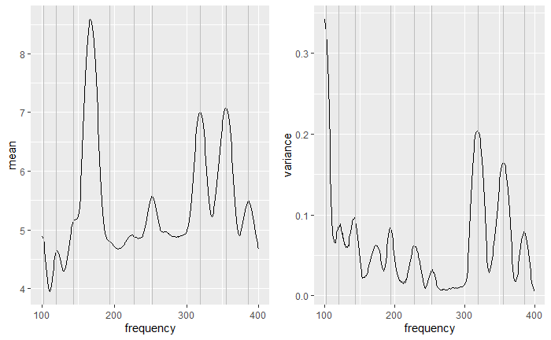

```r
library(gridExtra)
grid.arrange(p1, p2, ncol=2)
```

We will now plot the median response for the 15 vessels with the largest and lowest content in sodium oxide in order to have a sense of what frequencies are the good predictors for the sodium oxide concentration.

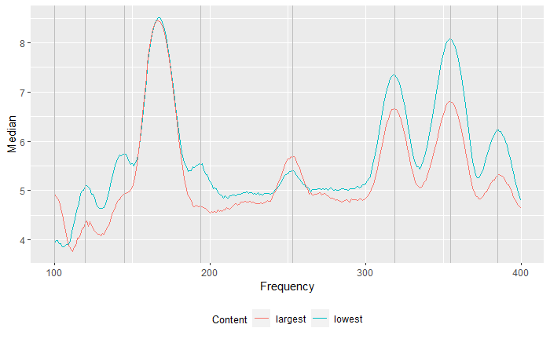

```r
low<-data %>%
  dplyr::arrange(Y1) %>%
  dplyr::slice(1:15) %>%
  dplyr::select(-Y1) %>%
  summarise_all(median)

high<-data %>%
  dplyr::arrange(Y1) %>%
  dplyr::slice((n()-15):n()) %>%
  dplyr::select(-Y1) %>%
  summarise_all(median)

df<-data.frame(frecuencia = seq(100,400,1), bajo = as.numeric(low), alto = as.numeric(high))

ggplot(df,aes(x=frecuencia)) +
  geom_line(aes(y=bajo,col="lowest")) +
  geom_line(aes(y=alto,col="largest")) +
  ylab("Median") +
  xlab("Frequency") +
  labs(color="Content") +
  theme(plot.title = element_text(size = 10, face = "bold"),
        legend.position="bottom",
        legend.title = element_text(size = 10)) +
  geom_vline(xintercept = c(100, 120, 145, 194, 253, 319, 355, 385),col="grey")
```

#LASSO regression on the Vessels data

Assuming a linear model y= b1x1+b2x2+…+gaussian_noise and finding parameters b by maximizing likelihood (equivalent to minimizing the sum of squares error - a.k.a OLS) will naturally yield to an over-fitted solution where we also model the noise and thus SSE will be 0. This is because there are potentially an infinite amount of ways to solve the system of 180 equations (constraints) and 301 parameters (the variables). We therefore aim to reduce the flexibility/complexity of the model by introducing a constraint/regularizer into the minimization problem that forces some parameters to 0. We decide to do so by penalizing the ℓ1 norm of the weights/parameters (LASSO method), which is equivalent to imposing a Laplacian prior.

```r
fit.lasso= cv.glmnet(x=as.matrix(data_logx), y=data_y$Y1, nfolds=10)
fit.lasso
```

```
Call:  cv.glmnet(x = as.matrix(data_logx), y = data_y$Y1, nfolds = 10)

Measure: Mean-Squared Error

     Lambda Index Measure      SE Nonzero
min 0.03762   100  0.4253 0.02974      31
1se 0.04325    97  0.4502 0.03166      29
```

Out of the 301 frequency, the LASSO selects 31 of them.

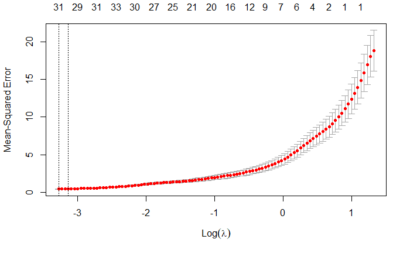

```r
plot(fit.lasso)
```

```r
b.lasso <- as.vector(coef(fit.lasso, s='lambda.min'))
names(b.lasso) <- c('intercept',colnames(data_logx))
b.lasso[b.lasso!=0]
```

```
  intercept        F100        F101        F102        F103        F104        F126        F127        F130
99.12685491  2.09930025  1.72051448  2.54949156  1.26220067  0.84355853 -0.66475481 -0.53127205 -1.05347025
       F132        F134        F135        F157        F167        F168        F169        F170        F187
-1.07722679 -0.51758897 -1.68994830  0.29062520 -6.28363211 -0.30932992 -1.69856597 -1.15842241 -0.30409361
       F196        F231        F232        F244        F246        F247        F283        F293        F300
-0.17695249 -1.02498380 -0.06281165  1.08813001  0.31236739  0.47326364 -0.90293306 -1.10759672 -1.30467148
       F303        F331        F342        F343        F344
-0.23098635 -0.02018058 -0.79131054 -0.23608622 -0.43830238
```

We now get the cross validated R^2:

```r
lasso_cv.mle = kfoldCV.lasso(x=as.matrix(data_logx), y=data_y$Y1, K=10, seed=1)
```

```
Starting cross-validation..........
```

```r
lasso_r2.mle= cor(lasso_cv.mle$pred, data_y$Y1)^2
lasso_r2.mle
```

```
[1] 0.9773764
```

#1. Prior eliciation to choose g:

Since we don’t have any information on which variables go in and which ones go out (in other words, which parameters b are 0 and which aren’t), we have to set a prior belief on each parameter that tells us how confident we are that they are 0 or not. Such prior will usually be centered around 0, and it will be more or less spread depending on how much sure we are that that variable the parameter is referring to has high or low explanatory power (highly spread = we believe the parameter b can be quite large = we believe it can have high explanatory power). Of course, if we have a huge amount of observations, then the prior will become irrelevant, but since that’s not usually the case, the choosing of the prior can have a big impact on the solution we get with our limited data, depending on how much we believe a priori on the existence of large or small parameters, and thus on the explanatory power of the covariates (similarly to what we would do with Ridge).

The parameter that refers to that spreadness is g, and since we don’t have any idea on which g is the proper one, we build different priors (making them more or less spread with different values of g) and, for each prior we sample different bi’s and then for each sample bi compute Tau (the amount of variance in Y explained by X with that specific bi). Then report the average of those Taus (which give you an approximation of the expected Tau that you would get with that specific prior). Notice how, if g is very large that means that we believe X has very high predictive power and that will produce Tau’s close to 1 (since that means that we allows for large parameters and probably overfitting). We then choose the g that produces an expected Tau reasonable within the context of the experiment.

We set our grid of values for g:

```r
gseq= seq(.000005,.0001,length=50)
gseq
```

```
 [1] 5.000000e-06 6.938776e-06 8.877551e-06 1.081633e-05 1.275510e-05 1.469388e-05 1.663265e-05 1.857143e-05
 [9] 2.051020e-05 2.244898e-05 2.438776e-05 2.632653e-05 2.826531e-05 3.020408e-05 3.214286e-05 3.408163e-05
[17] 3.602041e-05 3.795918e-05 3.989796e-05 4.183673e-05 4.377551e-05 4.571429e-05 4.765306e-05 4.959184e-05
[25] 5.153061e-05 5.346939e-05 5.540816e-05 5.734694e-05 5.928571e-05 6.122449e-05 6.316327e-05 6.510204e-05
[33] 6.704082e-05 6.897959e-05 7.091837e-05 7.285714e-05 7.479592e-05 7.673469e-05 7.867347e-05 8.061224e-05
[41] 8.255102e-05 8.448980e-05 8.642857e-05 8.836735e-05 9.030612e-05 9.224490e-05 9.418367e-05 9.612245e-05
[49] 9.806122e-05 1.000000e-04
```

```r
library(mvtnorm)
V= diag(ncol(data_logx)) #Covariance matrix of our multivariate normal prior is the identity matrix
beta= rmvnorm(1000, sigma= V) #generates data from the multivariate normal distribution - get 1,000 prior simulations for vector beta.
mat_data_logx = matrix(unlist(data_logx), nrow= nrow(data_logx), ncol= ncol(data_logx))
sse= rowSums((mat_data_logx %*% t(beta))^2) / nrow(data_logx)
```

For each value of g, we obtain the prior mean of τ over the prior simulations:

```r
r2= double(length(gseq))
for (i in 1:length(gseq)) {
  r2[i]= mean(sse * gseq[i] / (1 + sse * gseq[i]))
}
```

Plot the results:

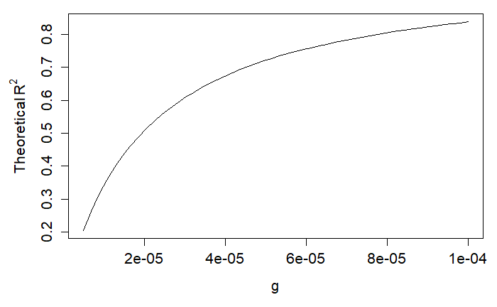

```r
par(mar=c(5,5,1,1), cex.lab=1.3, cex.axis=1.3)
plot(gseq, r2, type='l', xlab='g', ylab=expression(paste('Theoretical ',R^2)))
```

By pinning down the range of g that produces R^2 within the 0 and 1 range, we come to the conclusion that the values within the approximate interval [2e-05, 9e-05] make sense as they are restrictive enough so that it seems like they’d produce outcomes that won’t excessively overfit, but they’ll still keep relevant parameters maintaining plausible explanatory power. Considering that the LASSO method shown before obtained a CV-R^2 of around 0.98 even after reducing the amount of parameters to 31, and since we are more interested in understanding which frequencies really reflect the existence of Na2O content in the vessels, an example of plausible choice for g could be the one that a priori seems to generate a R^2 of around 0.75 (corresponding to a g value of around 6e-05). This makes the prior spread relatively small, pushing the parameters values towards 0, and making the final posterior distribution less centered towards the MLE.

We have thus concluded our prior elicitation for g parameter in a Bayesian regression with a normal shrinkage prior. We now move to the next question that requires running Bayesian model selecion on our data. Unfortunately, posterior sampling with Normal Shrinkage prior is not yet implemented on the mombf package, so we will run it considering a Zellner’s prior with g=taustd=1.

#2. Run a Bayesian model selection

We now run model selection setting g=1, Beta-Binomial(1,1) prior on the models (thus making all models equally likely in terms of the amount of parameters they contain) and Zellner’s prior on the regression coefficients

```r
fit.bayesreg <- modelSelection(x=as.matrix(data_logx), y=data_y$Y1, priorCoef=zellnerprior(taustd=1), priorDelta=modelbbprior(1,1))
```

```
Greedy searching posterior mode... Done.
Running Gibbs sampler........... Done.
```

```r
head(postProb(fit.bayesreg),10)#postProb outputs models posterior probilities p(γ|y) where the column modelid lists the variables included in each model
```

|  | modelid | family | pp |
| --- | --- | --- | --- |
| 1 | 2,3,5,16,36,58,68,232 | normal | 0.05574153 |
| 2 | 2,3,5,27,36,58,68,232 | normal | 0.05038944 |
| 3 | 2,3,5,15,36,58,68,232 | normal | 0.04006463 |
| 4 | 2,3,5,16,36,61,68,232 | normal | 0.03711679 |
| 5 | 2,3,5,15,36,61,68,232 | normal | 0.03609219 |
| 6 | 3,5,27,36,70,243 | normal | 0.03357562 |
| 7 | 2,3,5,27,36,58,68,230 | normal | 0.02635895 |
| 8 | 2,3,5,16,36,58,68,230 | normal | 0.02564360 |
| 9 | 2,3,5,19,36,58,68,232 | normal | 0.02137999 |
| 10 | 2,3,5,27,36,61,68,232 | normal | 0.02035178 |